# PRiSMA & ReMAPP Monitoring Report

2023-01-12

### PRiSMA MNH and ReMAPP Monitoring Report

#### **PRiSMA MNH:** Pregnancy Risk Stratification Innovation and Measurement Alliance (PRiSMA) Maternal and Newborn Health (MNH) Study: A multi-center, prospective cohort study of maternal, newborn, and infant health

#### **ReMAPP:** Redefining Anemia in Pregnancy and Postpartum

#### **Date report issued:** 2023-01-12

#### Includes data from synapse last updated:

#### Pakistan : 2023-01-06

#### Kenya : 2022-12-22

### **1. PRiSMA**

#### 📌 Table 1a: Pre-screening numbers for PRiSMA MNH Study for the most recent one week

*Value: This will provide a snapshot of weekly pre-screening progress, including reasons for ineligibility.*

|  | All sites | Kenya | Pakistan |
| --- | --- | --- | --- |
| **Pre-screening** |  |  |  |
| Pre-screened for PRiSMA, n (MNH00) | 324 | 160 | 164 |
| Eligible based on pre-screening, n | 36 | 18 | 18 |
| **Reason for exclusion in pre-screening, n(%)<sup>a</sup>** |  |  |  |
| No clinical signs of pregnancy | 0 (0.00) | 0 (0.00) | 0 (0.00) |
| Viable pregnancy with GA>=25 weeks | 199 (61.42) | 57 (35.62) | 142 (86.59) |
| Did not meet age requirement | 2 (0.62) | 2 (1.25) | 0 (0.00) |
| Outside catchment area | 55 (16.98) | 55 (34.38) | 0 (0.00) |
| Other reason | 29 (8.95) | 28 (17.50) | 1 (0.61) |
| Did not consent | 144 (44.44) | 0 (0.00) | 144 (87.80) |

<sup>a</sup> Denominator is pre- screened (MNH00 completed)

#### 📌 Table 1b: Cumulative pre-screening numbers for PRiSMA MNH Study

*Value: look at cumulative pre-screening distributions since the start of relaunch. If ineligible, distributions by exclusion criteria are listed below.*

|  | All sites | Kenya | Pakistan |
| --- | --- | --- | --- |
| **Pre-screening** |  |  |  |
| Pre-screened for PRiSMA, n (MNH00) | 1588 | 494 | 1094 |
| Eligible based on pre-screening, n | 273 | 66 | 207 |
| **Reason for exclusion in pre-screening, n(%)<sup>a</sup>** |  |  |  |
| No clinical signs of pregnancy | 0 (0.00) | 0 (0.00) | 0 (0.00) |
| Viable pregnancy with GA>=25 weeks | 969 (61.02) | 145 (29.35) | 824 (75.32) |
| Did not meet age requirement | 23 (1.45) | 23 (4.66) | 0 (0.00) |
| Outside catchment area | 158 (9.95) | 158 (31.98) | 0 (0.00) |
| Other reason | 108 (6.80) | 102 (20.65) | 6 (0.55) |
| Did not consent | 860 (54.16) | 0 (0.00) | 860 (78.61) |

<sup>a</sup> Denominator is pre- screened (MNH00 completed)

#### 📌 Table 2a: Enrollment numbers for PRiSMA MNH Study for the most recent one week

*Value: This will provide a snapshot of enrollment distributions on a weekly basis, including reasons for ineligibility.*

|  | All sites | Kenya | Pakistan |
| --- | --- | --- | --- |
| **Enrollment** |  |  |  |
| Screened for PRiSMA (MNH02), n | 66 | 17 | 49 |
| Enrolled in PRiSMA (MNH02), n(%) <sup>a</sup> | 58 (87.88) | 17 (100.00) | 41 (83.67) |
| **Reason not enrolled, n(%)<sup>a</sup>** |  |  |  |
| Did not meet age requirement | 0 (0.00) | 0 (0.00) | 0 (0.00) |
| Viable pregnancy with GA>=20 weeks by US | 7 (10.61) | 0 (0.00) | 7 (14.29) |
| Outside catchment area | 0 (0.00) | 0 (0.00) | 0 (0.00) |
| Did not consent | 1 (1.52) | 0 (0.00) | 1 (2.04) |

<sup>a</sup> denominator is n screened (MNH02 completed)

#### 📌 Table 2b: Cumulative enrollment numbers for PRiSMA MNH Study

*Value: look at cumulative enrollment and study progress distributions since the start of relaunch. If ineligible, distributions by exclusion criteria are listed below. .*

|  | All sites | Kenya | Pakistan |
| --- | --- | --- | --- |
| **Enrollment** |  |  |  |
| Screened for PRiSMA (MNH02), n | 780 | 57 | 723 |
| Enrolled in PRiSMA (MNH02), n(%) <sup>a</sup> | 582 (74.62) | 57 (100.00) | 525 (72.61) |
| **Reason not enrolled, n(%)<sup>a</sup>** |  |  |  |
| Did not meet age requirement | 0 (0.00) | 0 (0.00) | 0 (0.00) |
| Viable pregnancy with GA>=20 weeks by US | 156 (20.00) | 0 (0.00) | 156 (21.58) |
| Outside catchment area | 0 (0.00) | 0 (0.00) | 0 (0.00) |
| Did not consent | 42 (5.38) | 0 (0.00) | 42 (5.81) |

<sup>a</sup> denominator is n screened (MNH02 completed)

#### 📌 Table 3: Study Status for PRiSMA MNH Study

*Value: Value: look at current status of enrolled women*

|  | All sites | Kenya | Pakistan |
| --- | --- | --- | --- |
|  | (n=582) | (n=57) | (n=525) |
| **Study status, n (%)<sup>a</sup>** |  |  |  |
| Ongoing participants | 582 (100.00) | 57 (100.00) | 525 (100.00) |
| Completed 1-year follow-up after live birth or stillbirth | 0 (0.00) | 0 (0.00) | 0 (0.00) |
| Completed 42-day follow-up after spontaneous abortion (miscarriage) or induced abortion | 0 (0.00) | 0 (0.00) | 0 (0.00) |
| Mother died before completion | 0 (0.00) | 0 (0.00) | 0 (0.00) |
| Withdrew study | 0 (0.00) | 0 (0.00) | 0 (0.00) |
| Terminated from study | 0 (0.00) | 0 (0.00) | 0 (0.00) |
| Lost to follow-up | 0 (0.00) | 0 (0.00) | 0 (0.00) |

<sup>a</sup> denominator is n enrolled

#### 📌 Figure 1a: Cumulative Enrollment by Site and Week

*Value: Illustrate cumulative enrollment status by site over time*

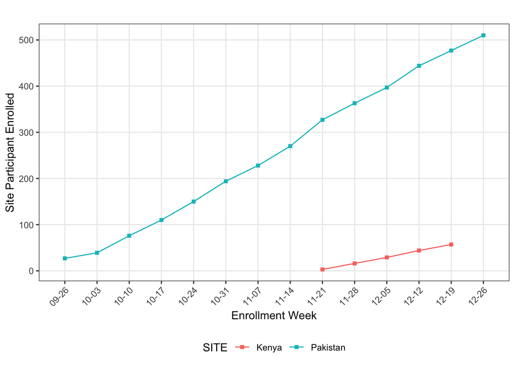

#### 📌 Figure 1b: Cumulative Enrollment by Week for Each Site

*Value: Compare expected and actual enrollment for each site over time*

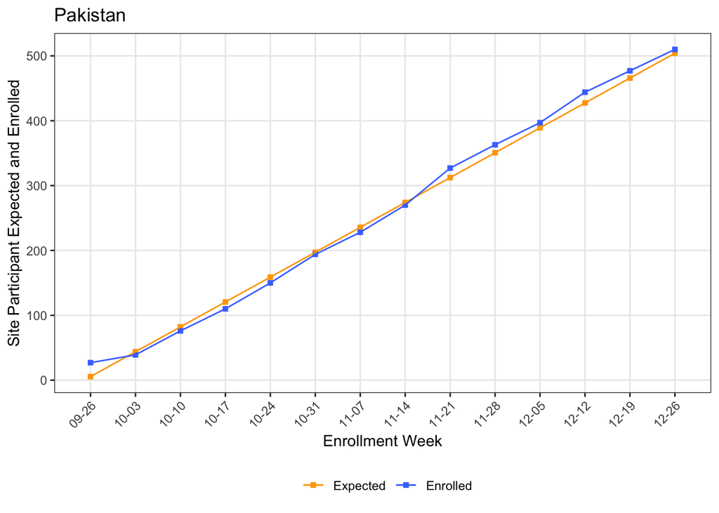

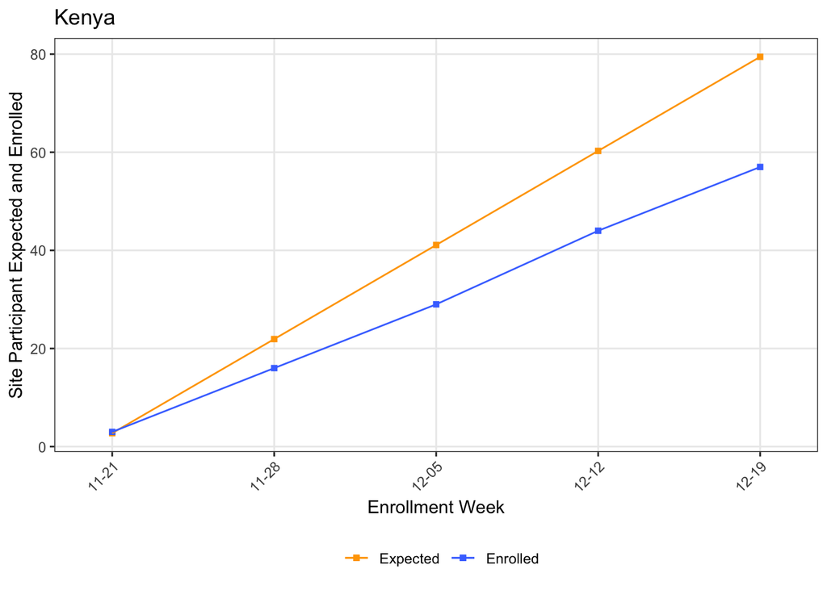

#### 📌 Table 4: ANC study visit & procedure completion metrics

*Value: Key metrics such as gestational age and percentage of women who have received an ultrasound at enrollment and 32 weeks are listed. Additionally, percent of all expected forms (late visit window has passed) that are filled out for each ANC visit are listed below. This will help us identify any gaps in visit completion or missing forms.*

|  | All sites | Kenya | Pakistan |
| --- | --- | --- | --- |
|  | (n=582) | (n=57) | (n=525) |
| **MNH01 Ultrasound** |  |  |  |
| Gestational Age at Enrollment, mean ± SD | 12.07 (3.72) | 13.88 (2.95) | 11.87 (3.75) |
| First trimester (<14 wks), n(%)<sup>a</sup> | 383 (65.81) | 32 (56.14) | 351 (66.86) |
| Ultrasound image at enrollment, n(%)<sup>a</sup> | 0 (0.00) | 0 (0.00) | 0 (0.00) |
| Ultrasound at ANC-32, n(%)<sup>a</sup> | 5 (0.86) | 0 (0.00) | 5 (0.95) |
| **ANC < 20, n(%)<sup>a</sup>** |  |  |  |
| MNH02 Enrollment Status | 582 (100.00) | 57 (100.00) | 525 (100.00) |
| MNH03 Sociodemographic | 523 (89.86) | 57 (100.00) | 466 (88.76) |
| MNH04 ANC Clinical Status | 581 (100.00) | 57 (100.00) | 524 (100.00) |
| MNH05 Maternal Anthropometry | 582 (100.00) | 57 (100.00) | 525 (100.00) |
| MNH06 Maternal POC | 582 (100.00) | 57 (100.00) | 525 (100.00) |
| MNH07 Maternal Specimen | 57 (100.00) | 57 (100.00) | 0 (0.00) |
| MNH08 Maternal Lab | 369 (100.00) | 57 (100.00) | 312 (100.00) |
| **ANC = 20, n(%)<sup>b</sup>** |  |  |  |
| MNH04 ANC Clinical Status | 152 (74.51) | 3 (60.00) | 149 (74.87) |
| MNH05 Maternal Anthropometry | 160 (76.19) | 3 (60.00) | 157 (76.59) |
| MNH06 Maternal POC | 160 (76.19) | 3 (60.00) | 157 (76.59) |
| MNH07 Maternal Specimen | 3 (100.00) | 3 (100.00) | 0 (0.00) |
| MNH08 Maternal Lab | 1 (1.01) | 0 (NaN) | 1 (1.01) |
| MNH25 Maternal Depression | 3 (2.24) | 3 (60.00) | 0 (0.00) |
| **ANC = 28, n(%)<sup>c</sup>** |  |  |  |
| MNH04 ANC Clinical Status | 32 (100.00) | 0 (0.00) | 32 (100.00) |
| MNH05 Maternal Anthropometry | 34 (100.00) | 0 (0.00) | 34 (100.00) |
| MNH06 Maternal POC | 34 (100.00) | 0 (0.00) | 34 (100.00) |
| MNH25 Maternal Depression | 218 (100.00) | 9 (100.00) | 209 (100.00) |
| MNH26 Maternal Fatigue | 208 (100.00) | 0 (0.00) | 208 (100.00) |
| **ANC = 32, n(%)<sup>d</sup>** |  |  |  |
| MNH04 ANC Clinical Status | 4 (100.00) | 0 (0.00) | 4 (100.00) |
| MNH05 Maternal Anthropometry | 5 (100.00) | 0 (0.00) | 5 (100.00) |
| MNH06 Maternal POC | 5 (100.00) | 0 (0.00) | 5 (100.00) |

<sup>a</sup> denominator is n enrolled  
<sup>b</sup> denominator is n completed ANC20 visit and missed on-time window with >22 weeks gestation  
<sup>c</sup> denominator is n completed ANC28 visit and missed on-time window with >30 weeks gestation  
<sup>d</sup> denominator is n completed ANC32 visit and missed on-time window with >33 weeks gestation

### **2. ReMAPP**

#### 📌 Table 1: ReMAPP healthy cohort eligibility

*Value: This table will be updated as lab measurements are updated and reported. Those who are unknown may move into eligible or ineligible categories based on updated lab reports.*

|  | All sites | Kenya | Pakistan |
| --- | --- | --- | --- |
|  | (n=582) | (n=57) | (n=525) |
| Total enrolled in ReMAPP | 0 | 0 | 0 |
| Eligible , n(%) | 0 (0.00) | 0 (0.00) | 0 (0.00) |
| Ineligible, n(%) | 567 (97.42) | 54 (94.74) | 513 (97.71) |
| Pending, n(%) | 15 (2.58) | 3 (5.26) | 12 (2.29) |

<sup>a</sup> denominator is n enrolled in PRiSMA

#### 📌 Table 2: Proportion of women eligible for ReMAPP healthy cohort by eligibility criteria.

*Value: This table will show the eligible number and percentage of all ReMAPP enrolled women for each criteria at baseline*

|  | All sites | Kenya | Pakistan |
| --- | --- | --- | --- |
|  | (n=582) | (n=57) | (n=525) |
| **Eligible for ReMAPP Aim 1 enrollment, n(%)<sup>a</sup>** |  |  |  |
| Aged 18 to 34 years | 200 (34.36) | 49 (85.96) | 151 (28.76) |
| Gestational age <14 weeks at enrollment | 383 (65.81) | 32 (56.14) | 351 (66.86) |
| BMI at baseline of >18.5 and <30 kg/m2 | 403 (69.24) | 45 (78.95) | 358 (68.19) |
| Mid-upper arm circumference (MUAC) > 23cm | 380 (65.29) | 54 (94.74) | 326 (62.10) |
| Height >153 cm | 353 (60.65) | 53 (92.98) | 300 (57.14) |
| Singleton pregnancy | 576 (98.97) | 57 (100.00) | 519 (98.86) |
| Systolic blood pressure <140 mmHg and diastolic blood pressure <90 mmHg | 574 (98.63) | 57 (100.00) | 517 (98.48) |
| <= 1 miscarriage in two consecutive pregnancies | 543 (93.30) | 56 (98.25) | 487 (92.76) |
| No previous preterm or low birth weight delivery | 467 (80.24) | 47 (82.46) | 420 (80.00) |
| No previous neonatal or fetal death | 396 (68.04) | 42 (73.68) | 354 (67.43) |
| No history of pregnancy complications | 441 (75.77) | 39 (68.42) | 402 (76.57) |
| Non-cigarette smoking, tobacco chewing, or betel nut use | 332 (57.04) | 57 (100.00) | 275 (52.38) |
| No reported alcohol consumption during pregnancy | 56 ( 9.62) | 56 (98.25) | NA |
| No known history or current chronic disease including cancer, kidney disease, and cardiac conditions | 569 (97.77) | 57 (100.00) | 512 (97.52) |
| **Lab Values, n(%)<sup>a</sup>** |  |  |  |
| No known history or current HIV | 551 (94.67) | 30 (52.63) | 521 (99.24) |
| No current malaria infection (per RDT) at baseline | 570 (97.94) | 46 (80.70) | 524 ( 99.81) |
| No Hepatitis B virus infection | 566 (97.25) | 56 (98.25) | 510 (97.14) |
| No Hepatitis C virus infection | 570 (97.94) | 57 (100.00) | 513 (97.71) |
| No hemoglobinopathiesb | 0 (0.00) | 0 (0.00) | 0 (0.00) |
| Not iron deficient (serum ferritin >15 mcg/L– adjusted for inflammation) | 0 (0.00) | 0 (0.00) | 0 (0.00) |
| No subclinical inflammation (CRP > 5 mg/L and/or AGP > 1 g/L) | 0 (0.00) | 0 (0.00) | 0 (0.00) |

<sup>a</sup> denominator is enrolled in PRiSMA